# Predicting Human Activity in Exercise with Machine Learning

Samantha Batcheller

7/19/2019

## Brief Overview

*“Six young health participants were asked to perform one set of 10 repetitions of the Unilateral Dumbbell Biceps Curl in five different fashions: exactly according to the specification (Class A), throwing the elbows to the front (Class B), lifting the dumbbell only halfway (Class C), lowering the dumbbell only halfway (Class D) and throwing the hips to the front (Class E).”*

Read more about the experiment and the where the data for this project comes from [here](http://web.archive.org/web/20161224072740/http:/groupware.les.inf.puc-rio.br/har#weight_lifting_exercises#ixzz5uAJSjqob)

## The Data

The training data for this project are available [here](https://d396qusza40orc.cloudfront.net/predmachlearn/pml-training.csv)

The test data are available [here](https://d396qusza40orc.cloudfront.net/predmachlearn/pml-testing.csv)

### Loading the Data & Necessary Packages

```r
library(caret)
library(rpart)
library(randomForest)
library(ggplot2)
library(gridExtra)
library(grid)
library(e1071)
library(knitr)
```

```r
set.seed(42)
urlTrain<-"https://d396qusza40orc.cloudfront.net/predmachlearn/pml-training.csv"
urlTest<-"https://d396qusza40orc.cloudfront.net/predmachlearn/pml-testing.csv"
download.file(urlTrain,destfile="pml-training.csv")
download.file(urlTest,destfile="pml-testing.csv")

data<-read.csv("pml-training.csv")
valid<-read.csv("pml-testing.csv")
```

Note that the “testing” data file has been renamed as the validation set and will not be used until the final predictions.

### Slicing

```r
inTrain<-createDataPartition(y=data$classe,p=0.75,list=FALSE)
training<-data[inTrain,]
testing<-data[-inTrain,]
dim(training)
```

```
## [1] 14718   160
```

```r
dim(testing)
```

```
## [1] 4904  160
```

```r
dim(valid)
```

```
## [1]  20 160
```

To get a testing set separate from the final validation set, the initial trainging set has been spliced to give a train and test set.

### Pre-Processing

First, the near zero variance variables are removed to shrink the data as they will have little impact ont he predictions.

```r
##remove near zero variance variables
nzv<-nearZeroVar(training)
training<-training[,-nzv]
testing<-testing[,-nzv]
valid<-valid[,-nzv]
##check dimensions to ensure they all have the same no. of cols
dim(training)
```

```
## [1] 14718   105
```

```r
dim(testing)
```

```
## [1] 4904  105
```

```r
dim(valid)
```

```
## [1]  20 105
```

```r
##check names of cols to see what is unnecessary
names(training)
```

```
##   [1] "X"                        "user_name"
##   [3] "raw_timestamp_part_1"     "raw_timestamp_part_2"
##   [5] "cvtd_timestamp"           "num_window"
##   [7] "roll_belt"                "pitch_belt"
##   [9] "yaw_belt"                 "total_accel_belt"
##  [11] "max_roll_belt"            "max_picth_belt"
##  [13] "min_roll_belt"            "min_pitch_belt"
##  [15] "amplitude_roll_belt"      "amplitude_pitch_belt"
##  [17] "var_total_accel_belt"     "avg_roll_belt"
##  [19] "stddev_roll_belt"         "var_roll_belt"
##  [21] "avg_pitch_belt"           "stddev_pitch_belt"
##  [23] "var_pitch_belt"           "avg_yaw_belt"
##  [25] "stddev_yaw_belt"          "var_yaw_belt"
##  [27] "gyros_belt_x"             "gyros_belt_y"
##  [29] "gyros_belt_z"             "accel_belt_x"
```

[output cut: 38 more lines]

Now, it can be seen from the column names remaining, columns 1-6 can be removed as they are just describing id numbers for participants and timestamps for the activity.

```r
##remove the first 6 cols
training<-training[,-c(1:6)]
testing<-testing[,-c(1:6)]
valid<-valid[,-c(1:6)]
##check dimensions to ensure they match no. of cols
dim(training)
```

```
## [1] 14718    99
```

```r
dim(testing)
```

```
## [1] 4904   99
```

```r
dim(valid)
```

```
## [1] 20 99
```

Lastly, the columns that are mostly consisting of NA values will be removed as they will also have little impact on the predictions.

```r
##determine which cols have over 95% NAs and remove them
MostNAs<-sapply(training, function(x) mean(is.na(x))) > 0.95
training<-training[,MostNAs==FALSE]
testing<-testing[,MostNAs==FALSE]
valid<-valid[,MostNAs==FALSE]
##check dimensions to ensure same no. of cols
dim(training)
```

```
## [1] 14718    53
```

```r
dim(testing)
```

```
## [1] 4904   53
```

```r
dim(valid)
```

```
## [1] 20 53
```

## Fitting Model Comparison

Now that the data has been pruned to an efficient size, three fit models will be compared to see which has the highest accuracy for the predictors left.

### Classification Tree Model

First, a *Classification Tree Model* is fitted with cross validation of 5 folds.

```r
set.seed(42)
trControl<-trainControl(method="cv", number=5)
modFitCT<-train(classe~.,method="rpart",data=training,trControl=trControl)
predCT<-predict(modFitCT,testing)
confusionMatrix(predCT,testing$classe)
```

```
## Confusion Matrix and Statistics
##
##           Reference
## Prediction    A    B    C    D    E
##          A 1257  380  386  379  123
##          B   21  319   28  132  118
##          C  117  250  441  293  246
##          D    0    0    0    0    0
##          E    0    0    0    0  414
##
## Overall Statistics
##
##                Accuracy : 0.4957
##                  95% CI : (0.4816, 0.5098)
##     No Information Rate : 0.2845
##     P-Value [Acc > NIR] : < 2.2e-16
##
##                   Kappa : 0.3415
##
##  Mcnemar's Test P-Value : NA
##
## Statistics by Class:
##
##                      Class: A Class: B Class: C Class: D Class: E
## Sensitivity            0.9011  0.33614  0.51579   0.0000  0.45949
## Specificity            0.6386  0.92440  0.77624   1.0000  1.00000
## Pos Pred Value         0.4978  0.51618  0.32739      NaN  1.00000
## Neg Pred Value         0.9420  0.85301  0.88361   0.8361  0.89154
## Prevalence             0.2845  0.19352  0.17435   0.1639  0.18373
## Detection Rate         0.2563  0.06505  0.08993   0.0000  0.08442
## Detection Prevalence   0.5149  0.12602  0.27467   0.0000  0.08442
## Balanced Accuracy      0.7699  0.63027  0.64602   0.5000  0.72974
```

```r
confusionMatrix(predCT,testing$classe)$overall[1]
```

```
##  Accuracy
## 0.4957178
```

#### Figure 1: Classification Tree Plot

```r
library(rattle)
```

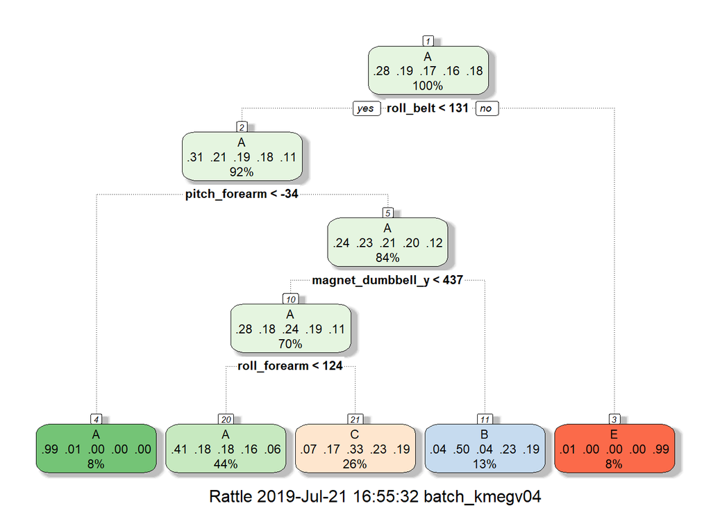

```r
fancyRpartPlot(modFitCT$finalModel)
```

### Gradient Boosting Machine Model

Next, a *Gradient Boosting Machine* is fitted with cross validation of 5 folds.

```r
modFitGBM<-train(classe~.,method="gbm",data=training,trControl=trControl,verbose=FALSE)
predGBM<-predict(modFitGBM,testing)
confusionMatrix(predGBM,testing$classe)
```

```
## Confusion Matrix and Statistics
##
##           Reference
## Prediction    A    B    C    D    E
##          A 1372   35    0    2    2
##          B   10  890   29    1   10
##          C    7   18  821   30    4
##          D    3    5    5  767   15
##          E    3    1    0    4  870
##
## Overall Statistics
##
##                Accuracy : 0.9625
##                  95% CI : (0.9568, 0.9676)
##     No Information Rate : 0.2845
##     P-Value [Acc > NIR] : < 2.2e-16
##
##                   Kappa : 0.9525
##
##  Mcnemar's Test P-Value : 1.436e-09
##
## Statistics by Class:
##
##                      Class: A Class: B Class: C Class: D Class: E
## Sensitivity            0.9835   0.9378   0.9602   0.9540   0.9656
## Specificity            0.9889   0.9874   0.9854   0.9932   0.9980
## Pos Pred Value         0.9724   0.9468   0.9330   0.9648   0.9909
## Neg Pred Value         0.9934   0.9851   0.9916   0.9910   0.9923
## Prevalence             0.2845   0.1935   0.1743   0.1639   0.1837
## Detection Rate         0.2798   0.1815   0.1674   0.1564   0.1774
## Detection Prevalence   0.2877   0.1917   0.1794   0.1621   0.1790
## Balanced Accuracy      0.9862   0.9626   0.9728   0.9736   0.9818
```

```r
confusionMatrix(predGBM,testing$classe)$overall[1]
```

```
##  Accuracy
## 0.9624796
```